# Data Visualization in Python using FastFood Restaurants Dataset of US

[figure not shown]

### 2. Loading Packages and Dataset

#### 2.1 Importing Packages

We will be inserting all the necessary packages for analysis.

```python
#import sys
#!{sys.executable} -m pip install pandas-profiling
import numpy as np                                                 # Implemennts milti-dimensional array and matrices
import pandas as pd
import pandas_profiling
import matplotlib.pyplot as plt                                    # Plotting library for Python programming language and it's numerical mathematics extension NumPy
import seaborn as sns                                              # Provides a high level interface for drawing attractive and informative statistical graphics
%matplotlib inline
sns.set()

import plotly
from plotly.offline import init_notebook_mode, iplot
from plotly.graph_objs import *
init_notebook_mode(connected=True)
import plotly.graph_objs as go

from subprocess import check_output
```

#### 2.2 Importing the Dataset

Here we would be importing the dataset to do the analysis and see the first few records.

```python
fastfood_restaurant_data = pd.read_csv("https://raw.githubusercontent.com/insaid2018/Term-1/master/Data/Projects/FastFoodRestaurants.csv")
fastfood_restaurant_data.head(10)
```

|  | address | city | country | keys | latitude | longitude | name | postalCode | province | websites |
| --- | --- | --- | --- | --- | --- | --- | --- | --- | --- | --- |
| 0 | 324 Main St | Massena | US | us/ny/massena/324mainst/-1161002137 | 44.92130 | -74.89021 | McDonald's | 13662 | NY | http://mcdonalds.com,http://www.mcdonalds.com/... |
| 1 | 530 Clinton Ave | Washington Court House | US | us/oh/washingtoncourthouse/530clintonave/-7914... | 39.53255 | -83.44526 | Wendy's | 43160 | OH | http://www.wendys.com |
| 2 | 408 Market Square Dr | Maysville | US | us/ky/maysville/408marketsquaredr/1051460804 | 38.62736 | -83.79141 | Frisch's Big Boy | 41056 | KY | http://www.frischs.com,https://www.frischs.com... |
| 3 | 6098 State Highway 37 | Massena | US | us/ny/massena/6098statehighway37/-1161002137 | 44.95008 | -74.84553 | McDonald's | 13662 | NY | http://mcdonalds.com,http://www.mcdonalds.com/... |
| 4 | 139 Columbus Rd | Athens | US | us/oh/athens/139columbusrd/990890980 | 39.35155 | -82.09728 | OMG! Rotisserie | 45701 | OH | http://www.omgrotisserie.com,http://omgrotisse... |
| 5 | 4182 Tonya Trl | Hamilton | US | us/oh/hamilton/4182tonyatrl/-1055723171 | 39.41760 | -84.47641 | Domino's Pizza | 45011 | OH | https://www.dominos.com/en/?redirect=homepage,... |
| 6 | 590 S Main St | Englewood | US | us/oh/englewood/590smainst/-1055723171 | 39.86969 | -84.29358 | Domino's Pizza | 45322 | OH | https://www.dominos.com/en/?redirect=homepagea... |
| 7 | 401 N Jennings St | Saluda | US | us/sc/saluda/401njenningsst/-1161002137 | 34.00598 | -81.77040 | McDonald's | 29138 | SC | http://www.mcdonalds.com |
| 8 | 205 W Church St | Batesburg | US | us/sc/batesburg/205wchurchst/-791445730 | 33.91335 | -81.53330 | Wendy's | 29006 | SC | http://www.wendys.com |
| 9 | 2711 W. Kings Highway Ste. 18 | Paragould | US | us/ar/paragould/2711wkingshighwayste18/-66712705 | 36.06107 | -90.52325 | Pizza Hut | 72450 | AR | http://www.pizzahut.com |

### 3. Data Profiling

For better understanding of the dataset, we will use Pandas functionality and profiling.

```python
fastfood_restaurant_data.shape
```

```
(10000, 10)
```

Fast food restaurants dataset contains **10,000 rows** and **10 columns**.

```python
fastfood_restaurant_data.columns
```

```
Index(['address', 'city', 'country', 'keys', 'latitude', 'longitude', 'name',
       'postalCode', 'province', 'websites'],
      dtype='object')
```

```python
fastfood_restaurant_data.dtypes
```

```
address        object
city           object
country        object
keys           object
latitude      float64
longitude     float64
name           object
postalCode     object
province       object
websites       object
dtype: object
```

```python
fastfood_restaurant_data.head(10)
```

|  | address | city | country | keys | latitude | longitude | name | postalCode | province | websites |
| --- | --- | --- | --- | --- | --- | --- | --- | --- | --- | --- |
| 0 | 324 Main St | Massena | US | us/ny/massena/324mainst/-1161002137 | 44.92130 | -74.89021 | McDonald's | 13662 | NY | http://mcdonalds.com,http://www.mcdonalds.com/... |
| 1 | 530 Clinton Ave | Washington Court House | US | us/oh/washingtoncourthouse/530clintonave/-7914... | 39.53255 | -83.44526 | Wendy's | 43160 | OH | http://www.wendys.com |
| 2 | 408 Market Square Dr | Maysville | US | us/ky/maysville/408marketsquaredr/1051460804 | 38.62736 | -83.79141 | Frisch's Big Boy | 41056 | KY | http://www.frischs.com,https://www.frischs.com... |
| 3 | 6098 State Highway 37 | Massena | US | us/ny/massena/6098statehighway37/-1161002137 | 44.95008 | -74.84553 | McDonald's | 13662 | NY | http://mcdonalds.com,http://www.mcdonalds.com/... |
| 4 | 139 Columbus Rd | Athens | US | us/oh/athens/139columbusrd/990890980 | 39.35155 | -82.09728 | OMG! Rotisserie | 45701 | OH | http://www.omgrotisserie.com,http://omgrotisse... |
| 5 | 4182 Tonya Trl | Hamilton | US | us/oh/hamilton/4182tonyatrl/-1055723171 | 39.41760 | -84.47641 | Domino's Pizza | 45011 | OH | https://www.dominos.com/en/?redirect=homepage,... |
| 6 | 590 S Main St | Englewood | US | us/oh/englewood/590smainst/-1055723171 | 39.86969 | -84.29358 | Domino's Pizza | 45322 | OH | https://www.dominos.com/en/?redirect=homepagea... |
| 7 | 401 N Jennings St | Saluda | US | us/sc/saluda/401njenningsst/-1161002137 | 34.00598 | -81.77040 | McDonald's | 29138 | SC | http://www.mcdonalds.com |
| 8 | 205 W Church St | Batesburg | US | us/sc/batesburg/205wchurchst/-791445730 | 33.91335 | -81.53330 | Wendy's | 29006 | SC | http://www.wendys.com |
| 9 | 2711 W. Kings Highway Ste. 18 | Paragould | US | us/ar/paragould/2711wkingshighwayste18/-66712705 | 36.06107 | -90.52325 | Pizza Hut | 72450 | AR | http://www.pizzahut.com |

```python
fastfood_restaurant_data.info()
```

```
<class 'pandas.core.frame.DataFrame'>
RangeIndex: 10000 entries, 0 to 9999
Data columns (total 10 columns):
address       10000 non-null object
city          10000 non-null object
country       10000 non-null object
keys          10000 non-null object
latitude      10000 non-null float64
longitude     10000 non-null float64
name          10000 non-null object
postalCode    10000 non-null object
province      10000 non-null object
websites      9535 non-null object
dtypes: float64(2), object(8)
memory usage: 781.3+ KB
```

```python
fastfood_restaurant_data.describe(include = 'all')
```

|  | address | city | country | keys | latitude | longitude | name | postalCode | province | websites |
| --- | --- | --- | --- | --- | --- | --- | --- | --- | --- | --- |
| count | 10000 | 10000 | 10000 | 10000 | 10000.000000 | 10000.000000 | 10000 | 10000 | 10000 | 9535 |
| unique | 9934 | 2775 | 1 | 10000 | NaN | NaN | 548 | 5289 | 52 | 3821 |
| top | 515 E Main St | Cincinnati | US | us/ga/fairburn/7800senoiard/1082608893 | NaN | NaN | McDonald's | 57701 | CA | http://mcdonalds.com,http://www.mcdonalds.com/... |
| freq | 3 | 119 | 10000 | 1 | NaN | NaN | 1886 | 23 | 676 | 1074 |
| mean | NaN | NaN | NaN | NaN | 37.552195 | -91.056132 | NaN | NaN | NaN | NaN |
| std | NaN | NaN | NaN | NaN | 5.050275 | 18.556339 | NaN | NaN | NaN | NaN |
| min | NaN | NaN | NaN | NaN | -6.244273 | -159.378915 | NaN | NaN | NaN | NaN |
| 25% | NaN | NaN | NaN | NaN | 34.028706 | -97.412631 | NaN | NaN | NaN | NaN |
| 50% | NaN | NaN | NaN | NaN | 38.298217 | -87.660930 | NaN | NaN | NaN | NaN |
| 75% | NaN | NaN | NaN | NaN | 41.116765 | -81.458351 | NaN | NaN | NaN | NaN |
| max | NaN | NaN | NaN | NaN | 64.840240 | 123.012361 | NaN | NaN | NaN | NaN |

```python
fastfood_restaurant_data.isna().sum()
```

```
address         0
city            0
country         0
keys            0
latitude        0
longitude       0
name            0
postalCode      0
province        0
websites      465
dtype: int64
```

From the above output we can see that websites has null values.

### 3.1 Pre-Profiling

```python
profile = pandas_profiling.ProfileReport(fastfood_restaurant_data)
profile.to_file(output_file="fastfood_restaurant_data_before_preprocessing.html")
```

From the pre-profiling, we find the below observations:

- Summary of the datatypes:
  - Numerical: latitude,longitude
  - Categorical: address,city,country,keys,name,postal code,province,websites.
- Country column has constant value as US.
- Websites has missing values.
- Keys column has all the unique values.
- The names of the restaurants are case sensitive i.e same restaurant name in capital letters is treated different from the restaurant name in small letters.

#### Pre-processing

Dropping the column country as the whole dataset belongs to the country US.

```python
fastfood_restaurant_data.drop('country', axis = 1,inplace = True)
print(fastfood_restaurant_data.columns)
```

```
Index(['address', 'city', 'keys', 'latitude', 'longitude', 'name',
       'postalCode', 'province', 'websites'],
      dtype='object')
```

Dropping the keys column as this column has all unique values and from this column we cannot draw any conclusions.

```python
fastfood_restaurant_data.drop('keys', axis = 1,inplace = True)
print(fastfood_restaurant_data.columns)
```

```
Index(['address', 'city', 'latitude', 'longitude', 'name', 'postalCode',
       'province', 'websites'],
      dtype='object')
```

Dropping the websites column as we cannot draw any conclusion for visualisation.

```python
fastfood_restaurant_data.drop('websites', axis = 1,inplace = True)
print(fastfood_restaurant_data.columns)
```

```
Index(['address', 'city', 'latitude', 'longitude', 'name', 'postalCode',
       'province'],
      dtype='object')
```

Change the restaurant names uniformly over the data.

```python
fastfood_restaurant_data['name'].nunique()
```

```
548
```

```python
restaurant_names = fastfood_restaurant_data['name'].unique()
import nltk
most_similar = []
for i in range(len(restaurant_names)):
    temp_similar = [restaurant_names[i]]
    for j in range(len(restaurant_names)):
        if restaurant_names[i] == restaurant_names[j]:
            continue
        if nltk.edit_distance(restaurant_names[i].lower(), restaurant_names[j].lower()) < 3:
            temp_similar.append(restaurant_names[j])
        if len(temp_similar) > 1:
            most_similar.append(temp_similar)
most_similar_word_count = 0
for i in most_similar:
      most_similar_word_count += len(i)
print("size of the most similar list:", most_similar_word_count)
```

```
size of the most similar list: 140483
```

```python
def sortFirst(val):
    return val[0]

most_similar.sort(key = sortFirst)
most_similar
unique_values = [list(x) for x in set(tuple(x) for x in most_similar)]
unique_values
```

```
[['Mcdonalds',
  "McDonald's",
  'McDonalds',
  "Mcdonald's",
  "Mc Donald's",
  'Mc Donalds',
  'McDonald’s'],
 ["Papa John's Pizza", 'Papa Johns Pizza', 'Papa John’s Pizza'],
 ['Chick-Fil-A', 'Chick-fil-A', 'Chick-fil-a'],
 ["D'angelo Grilled Sandwiches", "D'Angelo Grilled Sandwiches"],
 ['Mr Hero', 'Mr. Hero'],
 ["Popeye's Louisiana Kitchen", 'Popeyes Louisiana Kitchen'],
 ['Qdoba Mexican Eats', 'QDOBA Mexican Eats'],
 ['Carls Jr. / Green Burrito',
  "Carl's Jr. / Green Burrito",
  "Carl's Jr / Green Burrito"],
 ["Mc Donald's",
  "McDonald's",
  'McDonalds',
  "Mcdonald's",
  'Mcdonalds',
  'Mc Donalds',
  'McDonald’s'],
 ['Hot Dog On A Stick', 'Hot Dog on a Stick'],
 ['Thrashers French Fries', "Thrasher's French Fries"],
 ['Dunkin Donuts', "Dunkin' Donuts"],
 ["Carl's Jr. / Green Burrito",
  "Carl's Jr - Green Burrito",
  'Carls Jr. / Green Burrito',
  "Carl's Jr / Green Burrito"],
 ['Aw Restaurant', 'A&W Restaurant', 'A&w Restaurant'],
 ["Blake's LotaBurger", 'Blakes Lotaburger', "Blake's Lotaburger"],
 ['Sonic Drive in',
  'SONIC Drive In',
  'Sonic Drive-In',
  'SONIC Drive-In',
  'Sonic Drive In',
  'Sonic Drive-in'],
 ["Thrasher's French Fries", 'Thrashers French Fries'],
 ['Steak N Shake', "Steak 'n Shake", "Steak 'N Shake"],
```

[output cut: 157 more lines]

```
  'Sonic Drive-In',
  'SONIC Drive-In',
  'Sonic Drive In',
  'Sonic Drive in'],
 ['Spangles', "Spangle's"],
 ['Ll Hawaiian Barbecue', 'L&l Hawaiian Barbecue', 'L&L Hawaiian Barbecue'],
 ['Chick-fil-A', 'Chick-Fil-A', 'Chick-fil-a'],
 ['Long John Silvers', "Long John Silver's"],
 ["Culver's", 'Culvers'],
 ['TacoTime', 'Taco Time'],
 ['Taco del Mar', 'Taco Del Mar'],
 ['A&W All-American Food', 'A&W All American Food', 'A&W All-American Foods'],
 ['Jimmy Johns', "Jimmy John's"],
 ["Dunkin' Donuts", 'Dunkin Donuts'],
 ['Fosters Freeze', "Foster's Freeze"]]
```

Did some manual cleaning as there were little errors from nlp

```python
list_restaurants_similar = [["Domino's Pizza", 'Dominos Pizza'],
 ["Jimmy John's", 'Jimmy Johns'],
 ["Arby's", 'Arbys'],
 ['Kfc', 'KFC','KFC - Kentucky Fried Chicken', 'Kfc - Kentucky Fried Chicken'],
 ['Thrashers French Fries', "Thrasher's French Fries"],
 ['Culvers', "Culver's"],
 ['Back Yard Burgers', 'Backyard Burgers'],
 ['Aw Restaurant', 'A&W Restaurant', 'A&w Restaurant','A&w', 'A&W'],
 ["Wendy's", 'Wendys'],
 ['Taco Del Mar', 'Taco del Mar'],
 ["Carl's Jr. / Green Burrito",
  "Carl's Jr - Green Burrito",
  'Carls Jr. / Green Burrito',
  "Carl's Jr / Green Burrito"],
 ['Ll Hawaiian Barbecue', 'L&l Hawaiian Barbecue', 'L&L Hawaiian Barbecue'],
 ["Popeye's", 'Popeyes'],
 ["Steak 'n Shake", "Steak 'N Shake", 'Steak N Shake'],
 ['KFC/Taco Bell', 'KFC / Taco Bell'],
 ['Kum Go', 'Kum & Go'],
 ["McDonald's",
  'McDonalds',
  "Mcdonald's",
  "Mc Donald's",
  'Mcdonalds',
  'Mc Donalds',
  'McDonald’s'],
 ["Blake's LotaBurger", 'Blakes Lotaburger', "Blake's Lotaburger"],
 ["Papa John's Pizza", 'Papa Johns Pizza', 'Papa John’s Pizza','Papa Johns', "Papa John's"],
 ["Long John Silver's", 'Long John Silvers'],
 ["Popeye's Louisiana Kitchen", 'Popeyes Louisiana Kitchen'],
 ["Spangle's", 'Spangles'],
 ['DQ Grill & Chill', 'Dq Grill & Chill'],
 ['Dunkin Donuts', "Dunkin' Donuts"],
 ['Cook Out', 'Cook-Out', 'Cookout'],
 ['Jack in the Box', 'Jack In The Box'],
 ["Carl's Jr.", "Carl's Jr", 'Carls Jr'],
 ['Mr. Hero', 'Mr Hero'],
 ['Chick-Fil-A', 'Chick-fil-A', 'Chick-fil-a'],
 ['Port Of Subs', 'Port of Subs'],
 ["Topper's Pizza", 'Toppers Pizza'],
 ['Blimpie', 'BLIMPIE'],
 ['Qdoba Mexican Eats', 'QDOBA Mexican Eats'],
 ['Hot Dog on a Stick', 'Hot Dog On A Stick'],
 ["Popeye's Chicken & Biscuits", 'Popeyes Chicken & Biscuits'],
 ['Long John Silvers / A&W',
  "Long John Silver's / A&W",
  'Long John Silver/ A&W'],
 ['Rallys', "Rally's"],
 ['Fosters Freeze', "Foster's Freeze"],
 ["Checker's", 'Checkers'],
 ['SONIC Drive In',
  'Sonic Drive-In',
  'SONIC Drive-In',
  'Sonic Drive In',
  'Sonic Drive in',
  'Sonic Drive-in'],
 ['Taco Time', 'TacoTime'],
 ['Home Town Buffet', 'Hometown Buffet'],
 ['Subway', 'SUBWAY', 'SUBWAY®'],
 ['Hardees', "Hardee's"],
 ['B. Good', 'b.good'],
 ['A&W All-American Foods', 'A&W All-American Food', 'A&W All American Food'],
 ["D'angelo Grilled Sandwiches", "D'Angelo Grilled Sandwiches"],
 ["Frugal's", 'Frugals']]
```

```python
# let's create a dictionary to make name replace easier
match_name_dict = {}
for row in list_restaurants_similar:
    for similar_word in row:
        match_name_dict[similar_word] = row[0]
match_name_dict
```

```
{"Domino's Pizza": "Domino's Pizza",
 'Dominos Pizza': "Domino's Pizza",
 "Jimmy John's": "Jimmy John's",
 'Jimmy Johns': "Jimmy John's",
 "Arby's": "Arby's",
 'Arbys': "Arby's",
 'Kfc': 'Kfc',
 'KFC': 'Kfc',
 'KFC - Kentucky Fried Chicken': 'Kfc',
 'Kfc - Kentucky Fried Chicken': 'Kfc',
 'Thrashers French Fries': 'Thrashers French Fries',
 "Thrasher's French Fries": 'Thrashers French Fries',
 'Culvers': 'Culvers',
 "Culver's": 'Culvers',
 'Back Yard Burgers': 'Back Yard Burgers',
 'Backyard Burgers': 'Back Yard Burgers',
 'Aw Restaurant': 'Aw Restaurant',
 'A&W Restaurant': 'Aw Restaurant',
 'A&w Restaurant': 'Aw Restaurant',
 'A&w': 'Aw Restaurant',
 'A&W': 'Aw Restaurant',
 "Wendy's": "Wendy's",
 'Wendys': "Wendy's",
 'Taco Del Mar': 'Taco Del Mar',
 'Taco del Mar': 'Taco Del Mar',
 "Carl's Jr. / Green Burrito": "Carl's Jr. / Green Burrito",
 "Carl's Jr - Green Burrito": "Carl's Jr. / Green Burrito",
 'Carls Jr. / Green Burrito': "Carl's Jr. / Green Burrito",
 "Carl's Jr / Green Burrito": "Carl's Jr. / Green Burrito",
 'Ll Hawaiian Barbecue': 'Ll Hawaiian Barbecue',
 'L&l Hawaiian Barbecue': 'Ll Hawaiian Barbecue',
 'L&L Hawaiian Barbecue': 'Ll Hawaiian Barbecue',
 "Popeye's": "Popeye's",
 'Popeyes': "Popeye's",
 "Steak 'n Shake": "Steak 'n Shake",
 "Steak 'N Shake": "Steak 'n Shake",
 'Steak N Shake': "Steak 'n Shake",
 'KFC/Taco Bell': 'KFC/Taco Bell',
 'KFC / Taco Bell': 'KFC/Taco Bell',
 'Kum Go': 'Kum Go',
```

[output cut: 69 more lines]

```
 'Hometown Buffet': 'Home Town Buffet',
 'Subway': 'Subway',
 'SUBWAY': 'Subway',
 'SUBWAY®': 'Subway',
 'Hardees': 'Hardees',
 "Hardee's": 'Hardees',
 'B. Good': 'B. Good',
 'b.good': 'B. Good',
 'A&W All-American Foods': 'A&W All-American Foods',
 'A&W All-American Food': 'A&W All-American Foods',
 'A&W All American Food': 'A&W All-American Foods',
 "D'angelo Grilled Sandwiches": "D'angelo Grilled Sandwiches",
 "D'Angelo Grilled Sandwiches": "D'angelo Grilled Sandwiches",
 "Frugal's": "Frugal's",
 'Frugals': "Frugal's"}
```

```python
names = fastfood_restaurant_data['name'].values
print("size:", len(names))

# replace names with their dictionary value
for i in range(len(names)):
    if match_name_dict.get(names[i]) != None:
        names[i] = match_name_dict[names[i]]

fastfood_restaurant_data['names'] = names
```

```
size: 10000
```

```python
print("Number of unique restaurant:", fastfood_restaurant_data['name'].nunique())
```

```
Number of unique restaurant: 472
```

```python
fastfood_restaurant_data.name.value_counts()
```

```
McDonald's                                             2116
Burger King                                            1154
Taco Bell                                               873
Wendy's                                                 734
Arby's                                                  520
Kfc                                                     444
Subway                                                  406
SONIC Drive In                                          386
Domino's Pizza                                          359
Jack in the Box                                         201
Hardees                                                 194
Jimmy John's                                            163
Chick-Fil-A                                             146
Pizza Hut                                               128
Bojangles' Famous Chicken 'n Biscuits                   126
Five Guys                                                96
Dairy Queen                                              92
Whataburger                                              88
Carl's Jr.                                               85
Taco John's                                              77
Waffle House                                             74
Krystal                                                  64
White Castle                                             54
Checker's                                                48
Boston Market                                            45
Del Taco                                                 44
Quiznos                                                  42
Culvers                                                  39
Long John Silver's                                       38
Rallys                                                   34
                                                       ...
Rapid Ray's                                               1
Burgerville, USA                                          1
Cousins Subs of Green Bay - Oneida St. & Ramada Way       1
P. Terry's                                                1
J J Fish and Chicken                                      1
Aprisa Mexican Cuisine                                    1
Gianni's Pizza                                            1
Hub City Express                                          1
Cypress Best                                              1
Subway Citgo of Quarryville                               1
Lenny's Sub Shop                                          1
Lukes on Harlem                                           1
Freddy's Steakburger                                      1
Carl's / Green Burrito                                    1
Lime Ricky World                                          1
Chick-fil-a Truett's Luau                                 1
Jason's Deli                                              1
Quick                                                     1
Rubio's                                                   1
Rocky's                                                   1
Car's Late Night Delivery                                 1
Dan's Seafood & Chicken                                   1
Steak-out                                                 1
Cherry Hill Drive In Ice Cream                            1
Burger Time                                               1
Greek Oven Pizza and Wings                                1
Hotdoks                                                   1
Mariu Kebabberia Gastronomica                             1
AJ's Hotdogs & Gyros                                      1
Royal Buffet                                              1
Name: name, Length: 472, dtype: int64
```

### 3.2 Post Pandas Profiling

```python
profile = pandas_profiling.ProfileReport(fastfood_restaurant_data)
profile.to_file(output_file="fastfood_restaurant_data_after_preprocessing.html")
```

### 3.3 Hypothesis

This data will help to rank cities with the most and least fast food restaurants spread across the U.S.

### 4. Analysis/Questions

#### 4.1 Which is the most prevailed fast food restaurant across US?

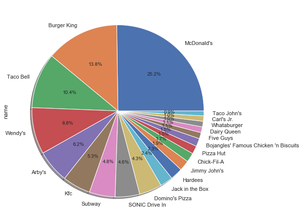

```python
plt.figure(figsize=(9,8))
fastfood_restaurant_data['name'].value_counts().head(20).plot.pie(autopct='%1.1f%%',shadow=True)
```

**Observation :** From the above plot,we observe that **Mc Donald's** is the most prevanlant fastfood restaurant in US.

[figure not shown]

#### 4.2 Spread of Mc Donald's over US

```python
mcd_data =  fastfood_restaurant_data[fastfood_restaurant_data["name"]=="McDonald's"]
mcd_data['city'].value_counts().head(15)
```

```
Cincinnati       20
Houston          12
Louisville       10
Las Vegas        10
Oklahoma City    10
Lexington         9
Minneapolis       9
Chicago           8
Evansville        8
Phoenix           8
Greenville        8
Brooklyn          7
Denver            7
Jackson           7
Columbus          7
Name: city, dtype: int64
```

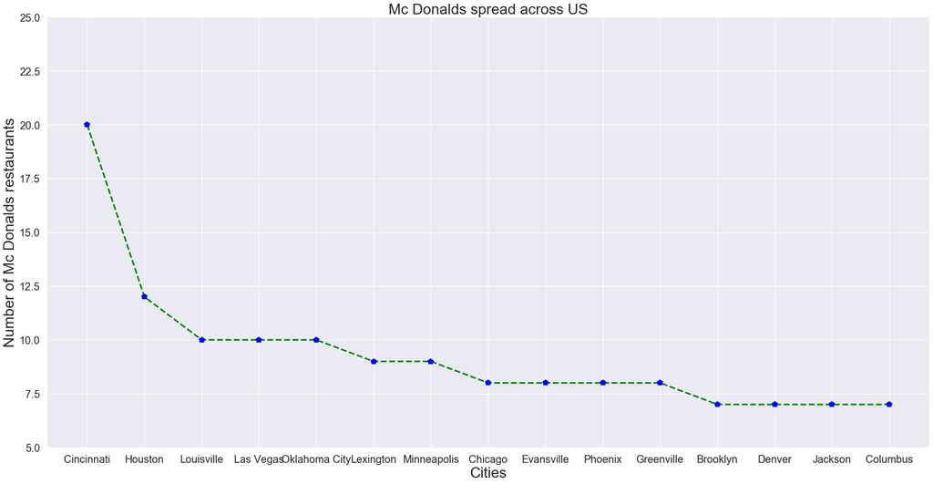

```python
plt.figure(figsize=(30,15))
x =mcd_data['city'].value_counts().head(15).index.tolist()
y = mcd_data['city'].value_counts().head(15)

plt.plot(x, y, color='green', linestyle='dashed', linewidth = 3,
         marker='p', markerfacecolor='blue', markersize=12)

plt.ylim(5,25)
plt.xlabel('Cities',fontsize=28)
plt.ylabel('Number of Mc Donalds restaurants',fontsize=28)
plt.title('Mc Donalds spread across US',fontsize=28)
plt.xticks(fontsize = 20)
plt.yticks(fontsize = 20)
plt.show()
```

#### 4.3 Spread of Fastfood restaurants across each province in US

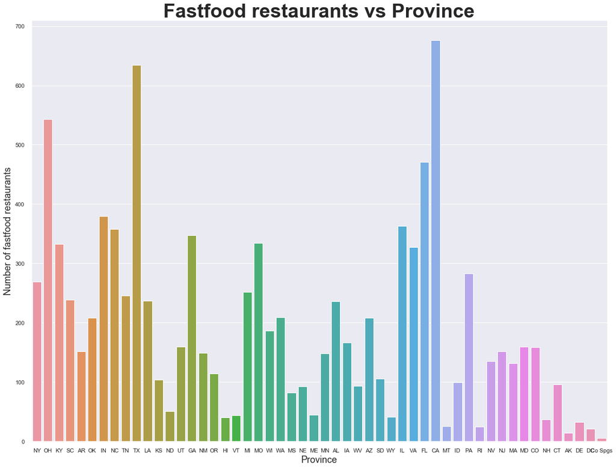

```python
plt.figure(figsize=(20,15))
sns.countplot(x="province", data=fastfood_restaurant_data)
plt.title(" Fastfood restaurants vs Province ",fontsize=38,fontweight="bold")
plt.ylabel("Number of fastfood restaurants",fontsize=18)
plt.xlabel("Province",fontsize=18)
plt.show()
```

```python
fastfood_restaurant_data['province'].value_counts().describe()
```

```
count     52.000000
mean     192.307692
std      155.515277
min        5.000000
25%       89.500000
50%      154.500000
75%      255.500000
max      676.000000
Name: province, dtype: float64
```

```python
fastfood_restaurant_data['province'].value_counts()[fastfood_restaurant_data['province'].value_counts() == 5]
```

```
Co Spgs    5
Name: province, dtype: int64
```

**Observation :** From the above,the average number of restaurants spread across 52 provinces of US is 192.

From that, we observe that Calfornia,Texas and Ohio provinces has the most fast food restaurants. The state with the fewest fast food restaurants is at Colorado Springs.

#### 4.4 Which are the top 3 cities with most fast food restaurants?

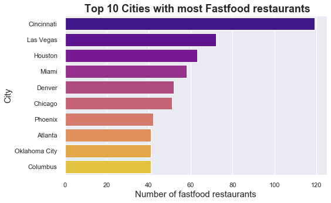

```python
plt.figure(figsize=(8,5))
sns.countplot(y="city", data=fastfood_restaurant_data, palette="plasma",
              order=fastfood_restaurant_data.city.value_counts().iloc[:10].index)
plt.title(" Top 10 Cities with most Fastfood restaurants",fontsize=18,fontweight="bold")
plt.xlabel("Number of fastfood restaurants",fontsize=15)
plt.ylabel("City",fontsize=15)
```

Top 3 cities with most fast food restaurants are **Cincinnati,LasVegas and Houstan.**

#### 4.5 Distribution of fast food restaurants in top 3 cities

```python
print("For Cincinnati:");
rt = fastfood_restaurant_data[fastfood_restaurant_data["city"]=="Cincinnati"]
restaurants = fastfood_restaurant_data[fastfood_restaurant_data["city"]=="Cincinnati"]["names"].value_counts()
print(restaurants);
print("\nNumber of restaurants in Cincinnati:"+str(len(restaurants)));

print("\nFor Las Vegas:");
restaurants1 = fastfood_restaurant_data[fastfood_restaurant_data["city"]=="Las Vegas"]["names"].value_counts()
print(restaurants1);
print("\nNumber of restaurants in Las Vegas:"+str(len(restaurants1)));

print("\nFor Houston:");
restaurants2 = fastfood_restaurant_data[fastfood_restaurant_data["city"]=="Houston"]["names"].value_counts()
print(restaurants2);
print("\nNumber of restaurants in Houston:"+str(len(restaurants2)));
```

```
For Cincinnati:
McDonald's                      20
Wendy's                         15
White Castle                    15
Taco Bell                       13
Burger King                     12
Arby's                           9
Kfc                              8
Gold Star Chili                  3
Steak 'n Shake                   3
Boston Market                    3
Jimmy John's                     2
Domino's Pizza                   2
Chick-Fil-A                      2
Rallys                           1
Tina's Carryout Restaurant       1
Long John Silver's               1
Richie's Restaurant              1
Pizza Hut                        1
Chipotle Mexican Grill           1
Rally's Hamburgers               1
Jack in the Box                  1
SONIC Drive In                   1
Skyline Chili                    1
Five Guys                        1
Penn Station East Coast Subs     1
Name: names, dtype: int64

Number of restaurants in Cincinnati:25

For Las Vegas:
McDonald's                    10
Domino's Pizza                 5
Pizza Hut                      4
Subway                         4
Del Taco                       4
Little Caesars Pizza           3
Jack in the Box                3
Dairy Queen                    3
Burger King                    2
```

[output cut: 36 more lines]

```
Kfc                 4
Wendy's             3
Popeye's            2
Domino's Pizza      2
SONIC Drive In      2
Five Guys           1
Chick-Fil-A         1
Pollo Tropical      1
Hardees             1
Mr Char-Burger      1
Schlotzsky's        1
Dairy Queen         1
Name: names, dtype: int64

Number of restaurants in Houston:18
```

```python
def percent_more_than_1_restaurants_city(list_restaurants,city):
    more_than_1_restaurants = list_restaurants[list_restaurants > 1]
    percent_more_than_1_restaurants = round(len(more_than_1_restaurants)/sum(list_restaurants)*100,2)
    print("City "+city+ " has "+ str(percent_more_than_1_restaurants)+ "% of total fastfood restaurants more than 1 restaurant open.")

percent_more_than_1_restaurants_city(restaurants, "Cincinnati")
percent_more_than_1_restaurants_city(restaurants1, "Las Vegas")
percent_more_than_1_restaurants_city(restaurants2, "Houston")
```

```
City Cincinnati has 10.92% of total fastfood restaurants more than 1 restaurant open.
City Las Vegas has 25.0% of total fastfood restaurants more than 1 restaurant open.
City Houston has 17.46% of total fastfood restaurants more than 1 restaurant open.
```

#### 4.6 Top 10 fastfood restaurants spread across Cincinnati,Las Vegas and Houstan:

```python
d = fastfood_restaurant_data[fastfood_restaurant_data["city"]== "Cincinnati"]
d["names"].value_counts()[:10]
```

```
McDonald's         20
Wendy's            15
White Castle       15
Taco Bell          13
Burger King        12
Arby's              9
Kfc                 8
Gold Star Chili     3
Steak 'n Shake      3
Boston Market       3
Name: names, dtype: int64
```

```python
np.ones(11)/10
```

```
array([0.1, 0.1, 0.1, 0.1, 0.1, 0.1, 0.1, 0.1, 0.1, 0.1, 0.1])
```

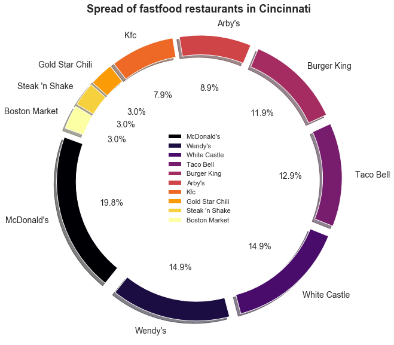

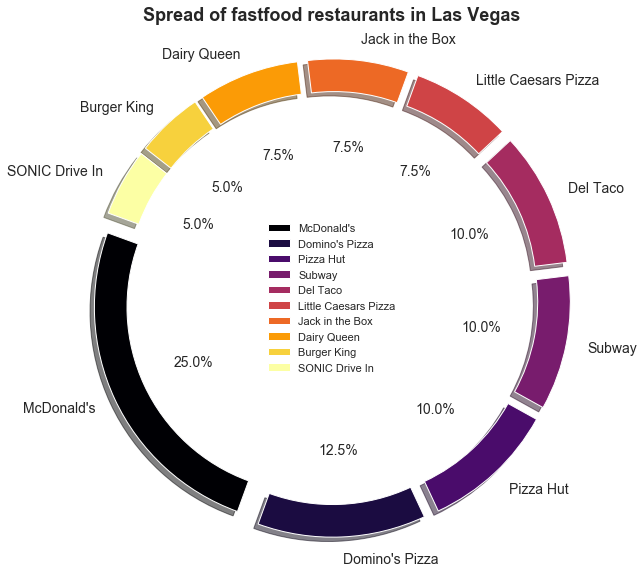

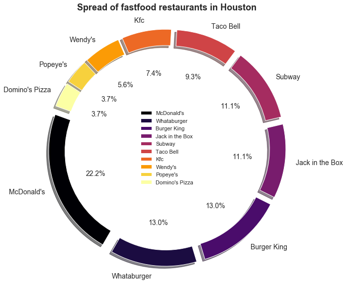

```python
def plot_donut_chart(city_name):
    data = fastfood_restaurant_data[fastfood_restaurant_data["city"]== city_name]
    counts =  data["names"].value_counts()[:10]
    space = np.ones(10)/10
    counts.plot(kind='pie', explode=space, fontsize=14, autopct='%3.1f%%', wedgeprops=dict(width=0.15),
                                       shadow=True, startangle=160, figsize=(10,10), cmap='inferno', legend=True)
    plt.ylabel('')
    plt.title("Spread of fastfood restaurants in "+ city_name,fontsize=18,fontweight="bold")
    plt.show()

plot_donut_chart("Cincinnati")
plot_donut_chart("Las Vegas")
plot_donut_chart("Houston")
```

#### 4.7 How many number of fast food restaurants are present per city in US?

```python
rest_count_by_city = fastfood_restaurant_data['city'].value_counts()
rest_count_by_city.describe()
```

```
count    2775.000000
mean        3.603604
std         5.761605
min         1.000000
25%         1.000000
50%         2.000000
75%         4.000000
max       119.000000
Name: city, dtype: float64
```

**Observation :** Many cities has only 1-4 fastfood restaurants opened and our mean number of fastfood restaurants opened is 3.6.

#### 4.8 How much percentage of cities have least number of restaurants?

```python
len(rest_count_by_city[rest_count_by_city == 1])
```

```
1226
```

```python
percentage_cities_least_fastfood_restaurants =  round(100*len(rest_count_by_city[rest_count_by_city == 1])/len(rest_count_by_city),2)
percentage_cities_least_fastfood_restaurants
```

```
44.18
```

```python
len(rest_count_by_city)
```

```
2775
```

```python
fig = go.Figure(go.Indicator(
    mode = "gauge+number",
    value = len(rest_count_by_city[rest_count_by_city == 1]),
    domain = {'x': [0, 1], 'y': [0, 1]},
    title = {'text': "Cities with only 1 fast food restaurant"},
    gauge = {'axis': {'range': [None, 2775]}}))

fig.show()
```

[interactive chart not shown]

#### 4.9 Number of cities with less than 5 restaurants

```python
len(rest_count_by_city[rest_count_by_city < 5])
```

```
2201
```

```python
percentage_cities_less_than_5_fastfood_restaurants =  round(100*len(rest_count_by_city[rest_count_by_city < 5])/len(rest_count_by_city),2)
percentage_cities_less_than_5_fastfood_restaurants
```

```
79.32
```

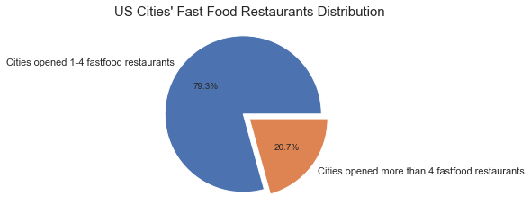

```python
plt.figure(figsize=(9,8))
fig,ax = plt.subplots()
total_cities_with_less_than_5_rests = len(rest_count_by_city[rest_count_by_city < 5])
total_cities_with_greater_equal_5_rests = fastfood_restaurant_data['city'].nunique() - total_cities_with_less_than_5_rests
values = [total_cities_with_less_than_5_rests, total_cities_with_greater_equal_5_rests]
ax.pie(values,
       labels=["Cities opened 1-4 fastfood restaurants", "Cities opened more than 4 fastfood restaurants"], autopct='%.1f%%', radius=1,
       explode = (0.1, 0))
ax.set_aspect('equal')
ax.set_title("US Cities' Fast Food Restaurants Distribution",fontsize =15)
plt.show()
```

**Observation :** From the above plot, we observe that 79.3% cities have 1-4 restaurants.

#### 4.1.0 Geographical Representation of fastfood restaurants spread across provinces in US

```python
states = fastfood_restaurant_data['province'].value_counts().index.tolist()
counts_of_restaurants_by_states = fastfood_restaurant_data['province'].value_counts()

data= [dict(type='choropleth',
            locations = states, # Spatial coordinates
            z = counts_of_restaurants_by_states, # Data to be color-coded
            locationmode = 'USA-states', # set of locations match entries in `locations`
            colorscale = 'Blues',
            marker_line_color = 'white',
            colorbar_title = "Number of Fast Fast Restaurants"
        )]
layout = dict(title = 'Fast Food Restaurants by Province in US',
              geo = dict(scope='usa'))
iplot(dict(data=data, layout=layout))
```

[interactive chart not shown]

#### 4.1.1 How are the fast food restaurants scattered?

```python
data = [dict(type = 'scattergeo',
            locationmode = 'USA-states',
            lon = fastfood_restaurant_data['longitude'],
            lat = fastfood_restaurant_data['latitude'],
            mode = 'markers',
            marker = dict(size = 3,
                opacity = 0.7,
                reversescale = True,
                autocolorscale = False,
                symbol = 'circle',
                line = dict(width=.5, color='black'),
                color = 'blue'
            )
        )]

layout = dict(title = 'US Fast Food Restaurants by location',
            geo = dict(scope='usa',
                showland = True,
                landcolor = "rgb(250, 250, 250)",
                subunitcolor = "rgb(217, 217, 217)"
            )
        )
iplot(dict(data=data, layout=layout ))
```

[interactive chart not shown]